# ST405/ST645 Bayesian Data Analysis

Assignment 4: Radon Analysis

Author

Prof. Niamh Cahill

## Instructions

Please submit your answers to this assignment by **December 10th, 4:00PM**. Include your JAGS model with your answers.

### Dataset

Radon is a naturally occurring radioactive gas. Its decay products are also radioactive; in high concentrations, they can cause lung cancer (several 1000 deaths/year in the USA). Radon levels vary greatly across US homes. We have data related to radon activity from the state of Minnesota, USA.

The dataset `radon_dat.csv` contains measurements of radon activity (`activity`) for houses within 85 counties in Minnesota. Some counties have more house measurements than others.

### Analysis

Assume that you want to estimate average radon levels for each county and that you want to share information across counties to account for the lack of measurements in some counties relative to others. You therefore decide to fit a model to the log(activity) measurements in a Hierarchical framework such that

$y_i|\alpha_{j[i]} \sim N(\alpha_{j[i]},\sigma)$

$\alpha_j|\mu_{\alpha},\sigma_{\alpha} \sim N(\mu_{\alpha},\sigma_{\alpha})$

- where $y_i$ = log(activity)
- $i = 1, \ldots, n$
- $j = 1, \ldots, m$
- $n$ is the number of observations
- $m$ is the number of unique counties.

Note, we log transform the activity data because we have a continuous measurement but it does not look normally distributed on the original scale. See the histogram plots below for a comparison of the original scale vs the log scale. In this case $\alpha_j$ can be interpreted as the average county-specific radon activity on the log scale.

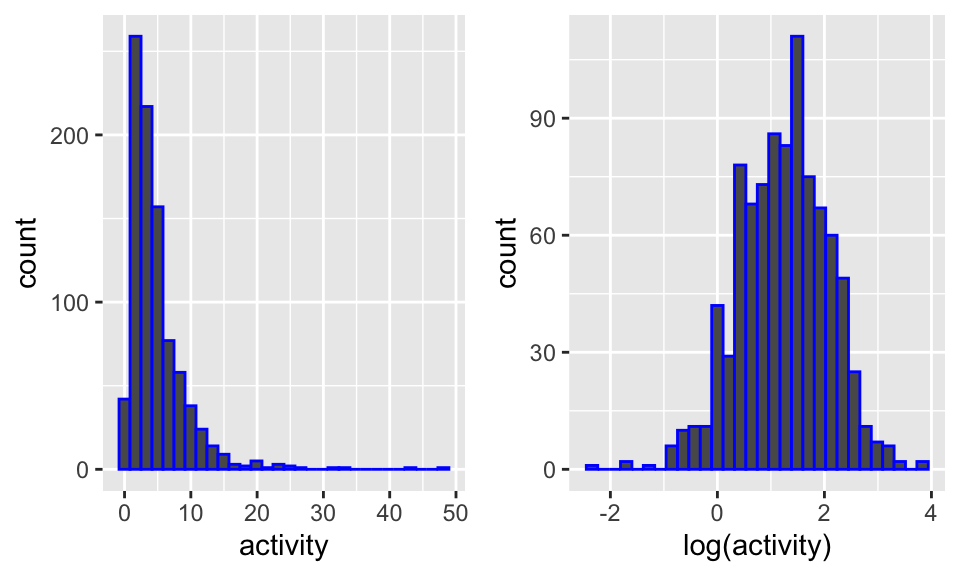

### Tasks

- **Task 1** **[15 Marks]**

Write the JAGS code and run the model to fit the Bayesian Hierarchical model outlined above to the log(activity) data.

- **Task 2**

Create the following plots and interpret them:

1. **[15 Marks]** Create a scatter plot with $\bar{y}_j$ = county level sample means for log(activity) on the x-axis vs $\hat{\alpha}_j$ = estimates of the $\alpha_j$’s from the hierarchical model on the y-axis. Add error bars for the $\alpha_j$’s that reflect the 68% credible intervals [once you have the interval values you can use `geom_errorbar()` to do this with `ggplot()`]. Add the identity line (i.e, the y = x line) to the plot [you can use `geom_abline(slope = 1, intercept = 0)` to do this with `ggplot()`]. Finally, add a horizontal line to the plot that represents the estimate of $\mu_{\alpha}$ from the model. Examine the plot and explain what it illustrates about the log(activity) estimates that you get from the hierarchical model.
2. **[10 Marks]** Create a scatter plot with the county level sample sizes (i.e., the number of measurements in each county) on the x-axis vs $\bar{y}_j - \hat{\alpha}_j$ on the y-axis. Add a horizontal line at 0. Examine the plot and explain what it illustrates about the log(activity) estimates that you get from the hierarchical model. How does what you learned here relate to what you learned from the plot in (i)?